## **“I affirm that I have received no support in taking this exam from any individual other than the Professor for this course”._____VJC__________ (Your initials)**

# Final Exam

**due by 5pm on Thursday, December 10th, 2015**

## Instructions

A. Fork the [Final repository](https://github.com/PADP8120-Fall2015/Final) from the course github page to your github account (i.e., just as you would with a homework assignment)

B. In RStudio, create a new project and link it to your newly forked github repo.

C. Resave the `Final_Fall2015.Rmd` file as `Final_Fall2015_FirstInitialLastName.Rmd` (e.g., Final_Fall2015_TScott.Rmd`)

D. Complete the final within your `Final_Fall2015_FirstInitialLastName.Rmd` file.

E. Make sure your final document renders as an `.html` file.

F. Please **email** to me all of the materials necessary for another person to run your R Markdown file, including: - The R project (`.Rproj`) file - The R Markdown document (`.Rmd`) of your analyses - An HTML document (`.html`) compiled from your R Markdown document. - Any data or other files needed to run the analyses in your R Markdown document.

## Guidelines

1. You may use any texts, help files, internet resources, web tutorials, etc. that you wish, but you may only discuss this exam (or receive any kind of personal assistance) from the Professor for this course. This includes a prohibition on receiving R help from any individual aside from the Professor in relation to this exam. To be clear, discussing this exam in any way with anyone besides the Professor for this course constitutes academic dishonesty. Your exam must have the following statement appended to the top (you may cut and paste it) and initialed. Exams without this statement will not be graded.
2. Your exam write-up should be clear and legible, with answers clearly indicated and work shown. Your exam must be produced in html (.html) document produced using R Markdown (i.e., an .Rmd file). Submit both your .html file and the .Rmd file used to generate it via github to the course midterm repo. If you are having trouble accomplishing this, please refer to the [guide](http://spia.uga.edu/faculty_pages/tyler.scott/teaching/PADP8120_Fall2015/Homeworks/submitting_homework.shtml).
3. The exam will be graded out of 100 points. Each problem is worth a designated number of points (shown below). Partial credit *may* by given for incorrect answers if I am able to see the process by which you went wrong (and thus see what you also did correctly), so it is to your advantage to show your work. Be sure to only include relevant information, as incorrect statements appended to correct responses will result in a penalty.
4. Your exam is **due by 5pm on Thursday, December 10th, 2015**; late exams will not be accepted.
5. I will address clarification questions until 8pm on Wednesday, December 9th. After that time, you are expected to complete the exam without any assistance.
6. Please contact me if you have any questions or concerns.

# Problems

## Set 1

The first set of questions pertain to Olympic gold medal-winning 100 meter sprint times for men and women.

```r
sprinters <- read.csv("https://raw.githubusercontent.com/vcoxon/Final/master/input/sprinters.csv")
```

| Variable | Description |
| --- | --- |
| `year` | Year of race |
| `finish` | completion time in seconds |
| `women` | indicator for female or male time |

1. (4 points) Estimate the model $\begin{aligned}[t] \mathtt{finish}_i &= \beta_0 + \beta_1 \mathtt{year}_i + \beta_2 \mathtt{women}_i + \beta_3 \mathtt{women}_i \times \mathtt{year}_i + \epsilon_i \end{aligned}$

```r
library(dplyr)
```

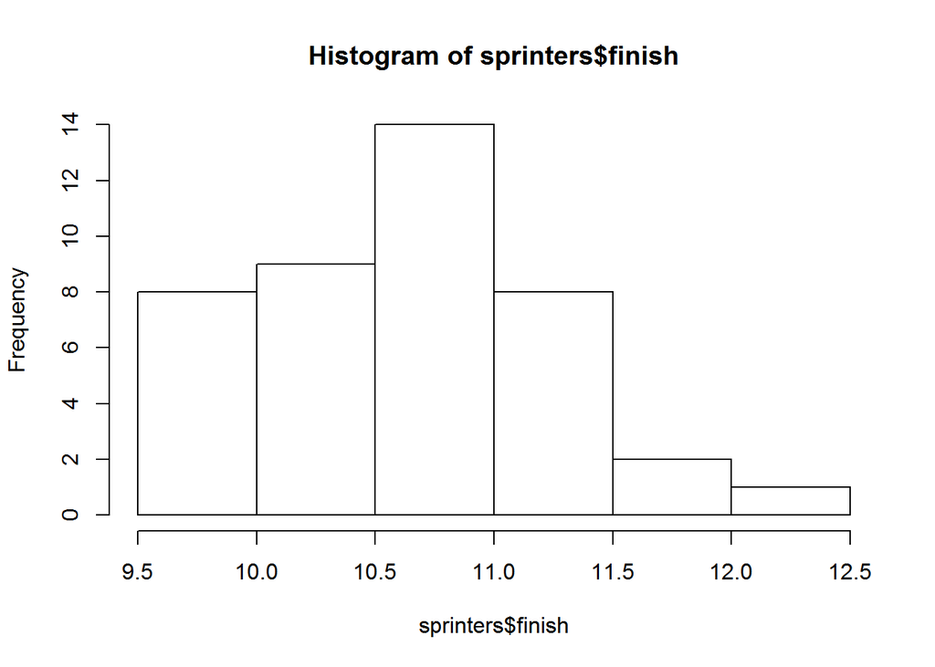

```r
library(ggplot2)
library(car)
library(magrittr)

hist(sprinters$finish)
```

```r
tapply(sprinters$finish, sprinters$women,mean)
```

```
##        0        1
## 10.31792 11.23000
```

```r
summary(sprint.model1 <- lm(finish ~ year + factor(women) + factor(women):year, data = sprinters))
```

```
##
## Call:
## lm(formula = finish ~ year + factor(women) + factor(women):year,
##     data = sprinters)
##
## Residuals:
##      Min       1Q   Median       3Q      Max
## -0.37579 -0.05460  0.00738  0.08276  0.32234
##
## Coefficients:
##                      Estimate Std. Error t value Pr(>|t|)
## (Intercept)         31.826453   2.128910  14.950  < 2e-16 ***
## year                -0.011006   0.001089 -10.104 2.56e-12 ***
## factor(women)1      12.520596   4.076141   3.072  0.00392 **
## year:factor(women)1 -0.005817   0.002074  -2.804  0.00791 **
## ---
## Signif. codes:  0 '***' 0.001 '**' 0.01 '*' 0.05 '.' 0.1 ' ' 1
##
## Residual standard error: 0.1707 on 38 degrees of freedom
## Multiple R-squared:  0.9275, Adjusted R-squared:  0.9218
## F-statistic: 162.1 on 3 and 38 DF,  p-value: < 2.2e-16
```

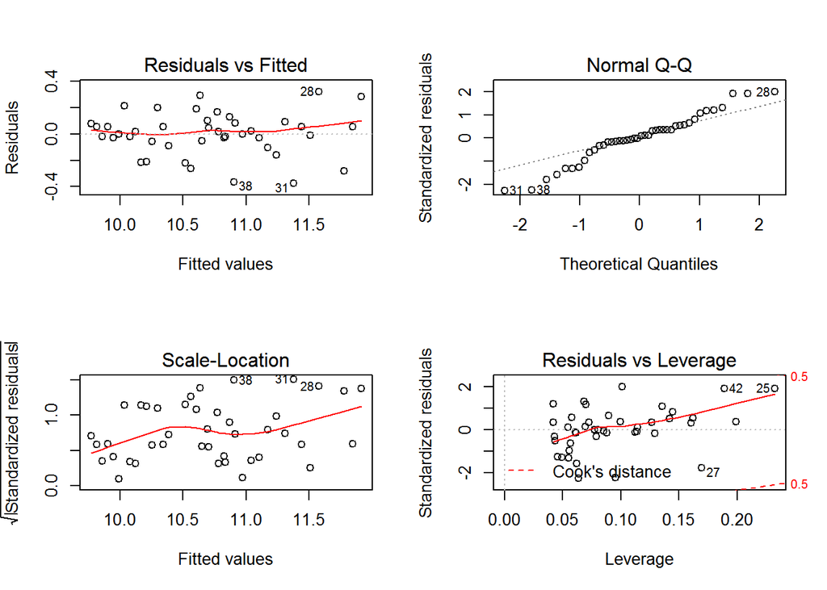

```r
sprint.model1 <- lm(finish ~ year + women + women:year, data = sprinters)
par(mfrow = c(2,2))
plot(sprint.model1)
```

2. (4 points) Given your results for the model above, what is the marginal effect of `year` for women? For men? Interpret each in a sentence.

_In this model, the marginal effect of ‘year’ for women is -0.011006 + -0.005817*woman. The marginal effect of ‘year’ for men is -0.011006; it is the predicted effect of one year on the finish times when woman = 0._

3. (4 points) Create a plot of the fitted values (with confidence intervals) with respect to `year`, grouped by `women`. Do not use `geom_smooth()`.

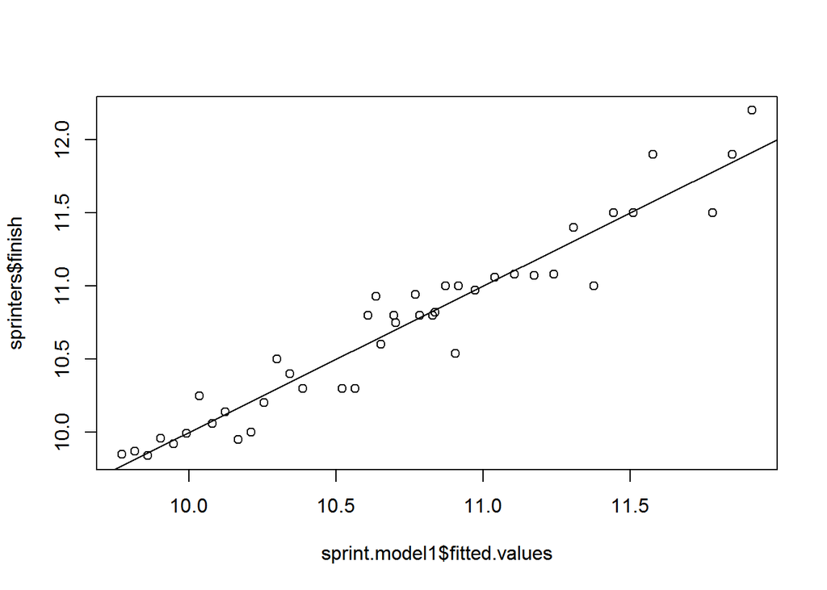

```r
par(mfrow = c(1,1))
plot(sprinters$finish ~ sprint.model1$fitted.values)
abline(0,1)
```

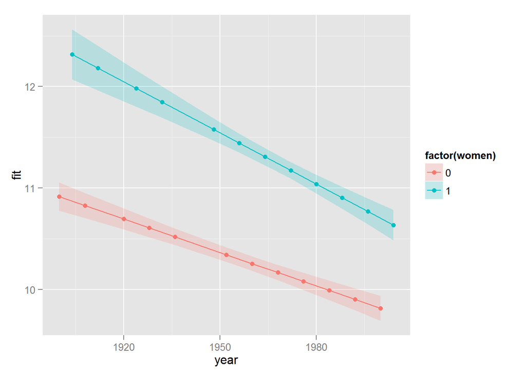

```r
year = seq(from = 1928, to = 2004, by = 4) #Because I do not have values for women prior to 1928.

#Option1
pred1_df <- data.frame(year = sprinters$year, women = c(0,1))
pred1 <- predict(sprint.model1, newdata = pred1_df, interval = "confidence")
pred1 <- cbind(pred1, pred1_df)

ggplot(pred1, aes(x = year, y = fit, ymin = lwr, ymax = upr, colour = factor(women), fill = factor(women))) + geom_point() + geom_ribbon(alpha = 0.2, colour = NA) + geom_line()
```

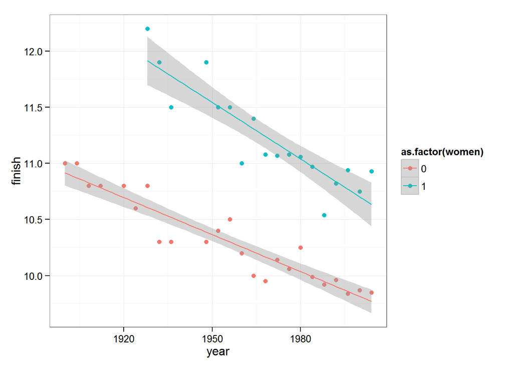

```r
#Option2
ggplot(sprinters,aes(x=year,y=finish,colour=as.factor(women))) + geom_point() + theme_bw() + stat_smooth(method='lm')
```

###### I TRIED THIS FROM LAB 14, but was unsucccessful. Please let me know how to fix this when you send out the grades.

```r
#coef.df = data.frame(Women.Intercept = c(coef(sprint.model1)[1],coef(sprint.model1)[1]+coef(sprint.model1)[3]), Women.Slope = c(coef(sprint.model1)[2],coef(sprint.model1)[2]+coef(sprint.model1)[4]), Women = c('0','1'))

#ggplot() + geom_point(data=sprinters, aes(y = finish,x = year,colour = factor(women))) + geom_abline(aes(intercept = Women.Intercept,slope = Women.Slope,colour= Women, data=coef.df) + theme_bw() + theme(legend.position = c(0.7,0.1), legend.direction = 'horizontal') + scale_colour_brewer('Women',palette = 2,type = 'qual') +  ylab('100 Meter Sprint Gold Medal Winning Finish Times') + xlab('Year of Olympic Games'))
```

4. (2 points) Create the same plot as in the previous problem for the model $\begin{aligned}[t] \log (\mathtt{finish}_i) &= \beta_0 + \beta_1 \mathtt{year}_i + \beta_2 \mathtt{women}_i + \beta_3 \mathtt{year}_i \times \mathtt{women}_i + \epsilon_i \end{aligned}$

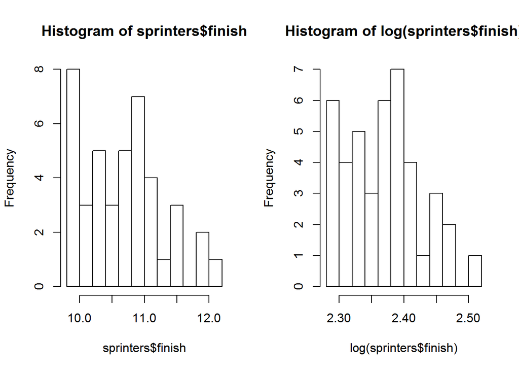

```r
par(mfrow = c(1,2))
hist(sprinters$finish, breaks = 10)
hist(log(sprinters$finish), breaks = 10)
```

```r
summary(sprint.model2 <- lm(log(finish) ~ year + factor(women) + factor(women):year, data = sprinters))
```

```
##
## Call:
## lm(formula = log(finish) ~ year + factor(women) + factor(women):year,
##     data = sprinters)
##
## Residuals:
##       Min        1Q    Median        3Q       Max
## -0.034032 -0.004757  0.000730  0.007021  0.028050
##
## Coefficients:
##                       Estimate Std. Error t value Pr(>|t|)
## (Intercept)          4.405e+00  1.929e-01  22.842  < 2e-16 ***
## year                -1.060e-03  9.867e-05 -10.745 4.46e-13 ***
## factor(women)1       9.300e-01  3.693e-01   2.519   0.0161 *
## year:factor(women)1 -4.217e-04  1.879e-04  -2.244   0.0307 *
## ---
## Signif. codes:  0 '***' 0.001 '**' 0.01 '*' 0.05 '.' 0.1 ' ' 1
##
## Residual standard error: 0.01547 on 38 degrees of freedom
## Multiple R-squared:  0.9306, Adjusted R-squared:  0.9251
## F-statistic: 169.8 on 3 and 38 DF,  p-value: < 2.2e-16
```

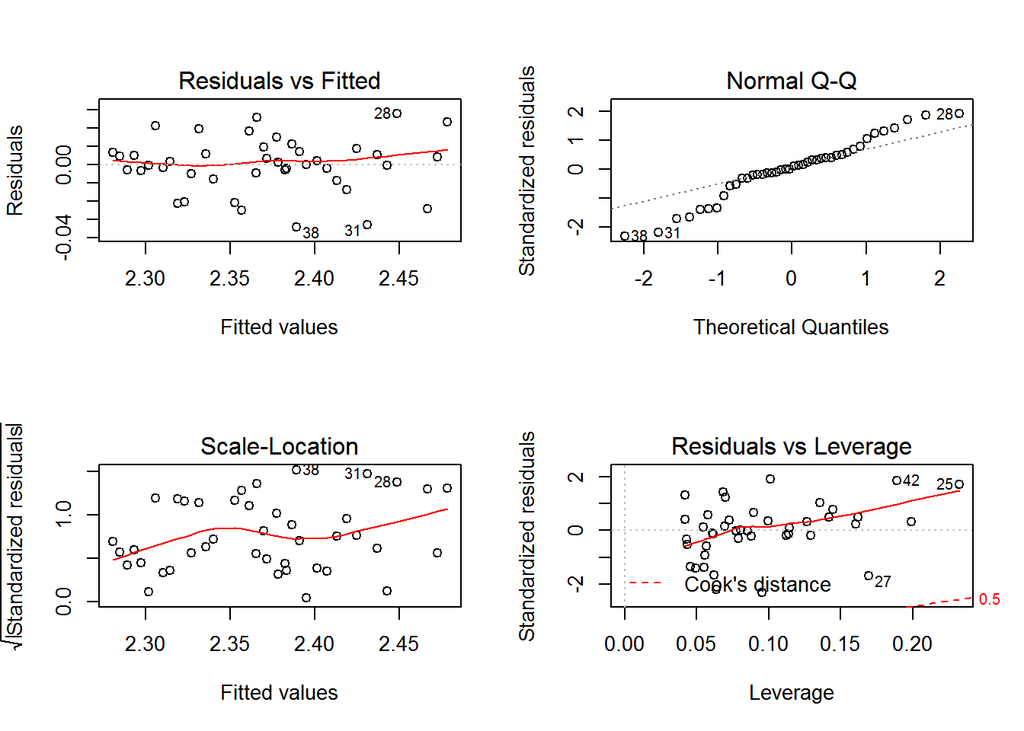

```r
par(mfrow = c(2,2))
plot(sprint.model2)
```

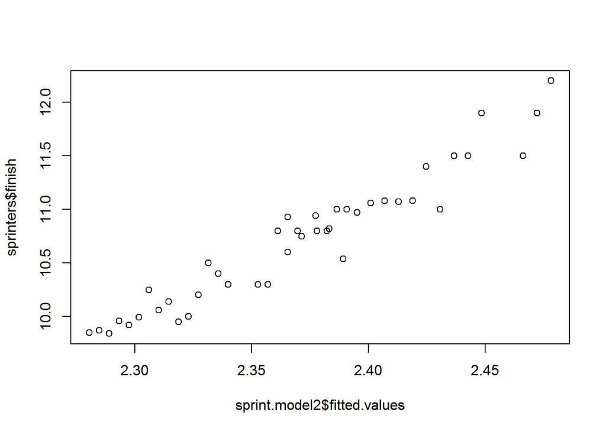

```r
par(mfrow = c(1,1))
plot(sprinters$finish ~ sprint.model2$fitted.values)
abline(0,1)
```

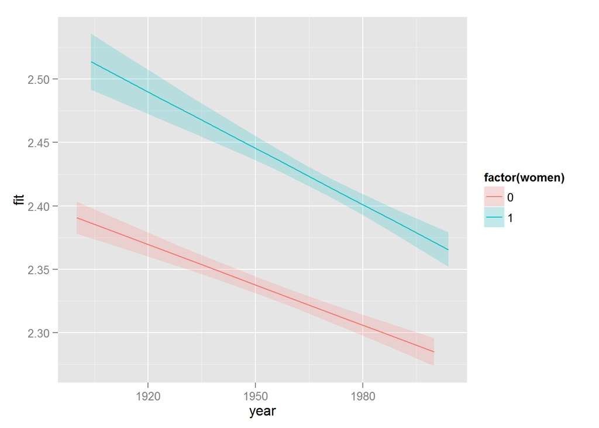

```r
pred2_df <- data.frame(year = sprinters$year, women = c(0,1))
pred2 <- predict(sprint.model2, newdata = pred2_df, interval = "confidence")
pred2 <- cbind(pred2, pred2_df)

ggplot(pred2, aes(x = year, y = fit, ymin = lwr, ymax = upr, colour = factor(women), fill = factor(women))) + geom_line() + geom_ribbon(alpha = 0.2, colour = NA)
```

5. (4 points) Explain in no more than 2 sentences how this specification differs from the prior specification.

Model2log differs in specification from Model1 because the outcome variable ‘finish’ has been log transformed to address this variable’s obvious right skew. This transformation will change how we interpret the explanatory variable Beta coefficients to “a one unit increase in Xi is predicted to increase log(finish) by $exp$ $\beta{X}_i$.

6. (6 points) Rerun the analysis and recreate the plot for the model: $\begin{aligned}[t] \mathtt{Finish}_i &= \beta_0 + \beta_1 \mathtt{year}_i + \beta_2 \mathtt{women}_i + \beta_3 \mathtt{year}_i × \mathtt{women}_i \\ & + \beta_4 \mathtt{year}_i^2 + \beta_5 \mathtt{year}_i^2 × \mathtt{women}_i + \epsilon_i \end{aligned}$

```r
summary(sprint.model3 <- lm(finish ~ year + factor(women) + factor(women):year + I(year^2) + I(year^2) * factor(women), data = sprinters))
```

```
##
## Call:
## lm(formula = finish ~ year + factor(women) + factor(women):year +
##     I(year^2) + I(year^2) * factor(women), data = sprinters)
##
## Residuals:
##      Min       1Q   Median       3Q      Max
## -0.35651 -0.05734 -0.00422  0.09817  0.35561
##
## Coefficients:
##                            Estimate Std. Error t value Pr(>|t|)
## (Intercept)               2.247e+02  1.422e+02   1.580    0.123
## year                     -2.087e-01  1.457e-01  -1.432    0.161
## factor(women)1            4.751e+02  3.267e+02   1.454    0.155
## I(year^2)                 5.064e-05  3.733e-05   1.357    0.183
## year:factor(women)1      -4.750e-01  3.328e-01  -1.427    0.162
## factor(women)1:I(year^2)  1.189e-04  8.475e-05   1.403    0.169
##
## Residual standard error: 0.1609 on 36 degrees of freedom
## Multiple R-squared:  0.9391, Adjusted R-squared:  0.9306
## F-statistic:   111 on 5 and 36 DF,  p-value: < 2.2e-16
```

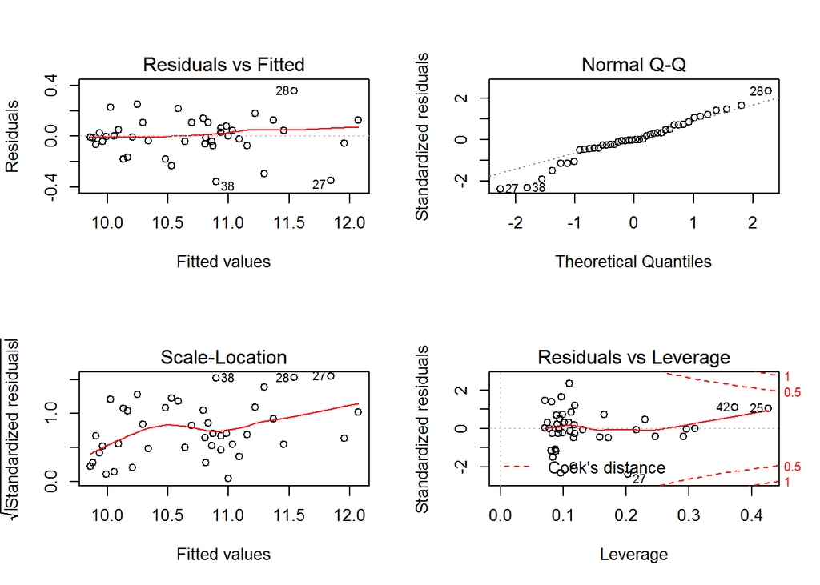

```r
par(mfrow = c(2,2))

plot(sprint.model3)
```

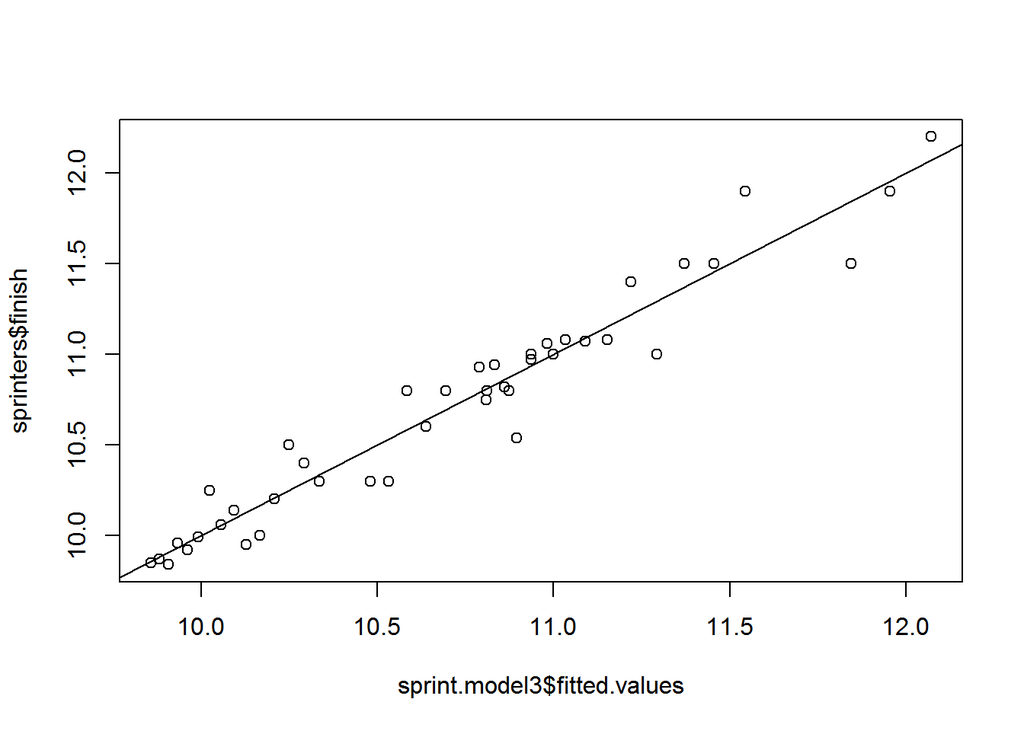

```r
par(mfrow = c(1,1))
plot(sprinters$finish ~ sprint.model3$fitted.values)
abline(0,1)
```

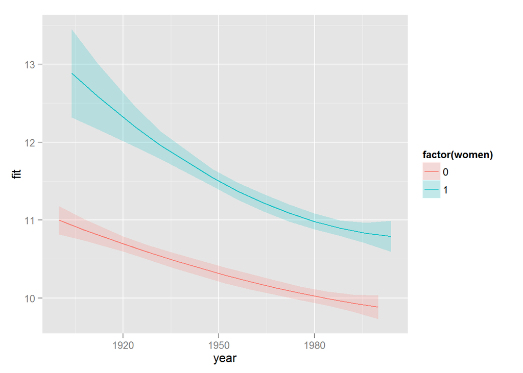

```r
pred3_df <- data.frame(year = sprinters$year, women = c(0,1))
pred3 <- predict(sprint.model3, newdata = pred3_df, interval = "confidence")
pred3 <- cbind(pred3, pred3_df)

ggplot(pred3, aes(x = year, y = fit, ymin = lwr, ymax = upr, colour = factor(women), fill = factor(women))) + geom_line() + geom_ribbon(alpha = 0.2, colour = NA)
```

7. (4 points) Explain in 2-3 sentences how this specification differs from the previous models.

8. (4 points) Compare the visual fit of these models to the data within the observed period. Which (if any) do you find to be plausible fits?

**Key Asssumptions**  
*1. Linear Relationship*  
*2. Residuals are ‘iid’; identically & independently distributed (errors $\epsilon_i$ do not affect each other).* *3. Nothing about $\beta_1$ affects $\beta_2$, …, $\beta_k$.*

###### Condition 1: Linearity

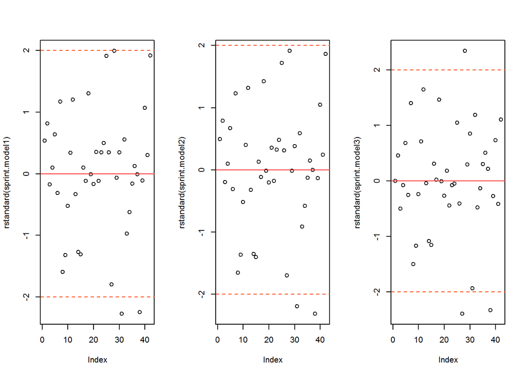

```r
par(mfrow = c(1,3))
plot(rstandard(sprint.model1))
abline(h = 0, lty = 1, col = "firebrick1")
abline(h= 2,lty=2, col = "orangered")
abline(h=-2,lty=2, col = "orangered")
plot(rstandard(sprint.model2))
abline(h = 0, lty = 1, col = "firebrick1")
abline(h= 2,lty=2, col = "orangered")
abline(h=-2,lty=2, col = "orangered")
plot(rstandard(sprint.model3))
abline(h = 0, lty = 1, col = "firebrick1")
abline(h= 2,lty=2, col = "orangered")
abline(h=-2,lty=2, col = "orangered")
```

###### Condition 2: Nearly Normal Residuals

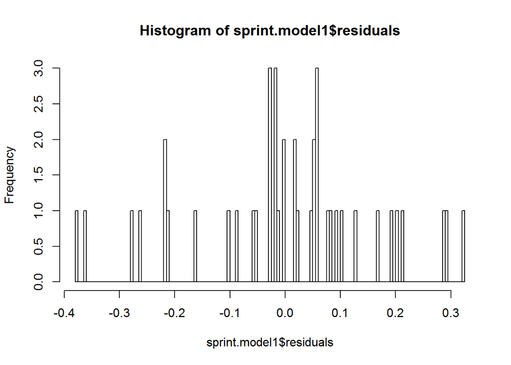

```r
hist(sprint.model1$residuals, breaks = 100)
```

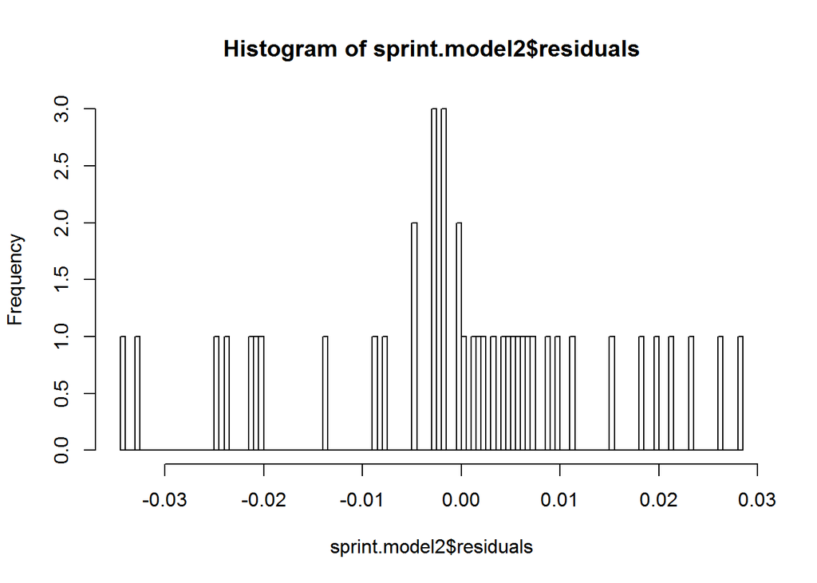

```r
hist(sprint.model2$residuals, breaks = 100)
```

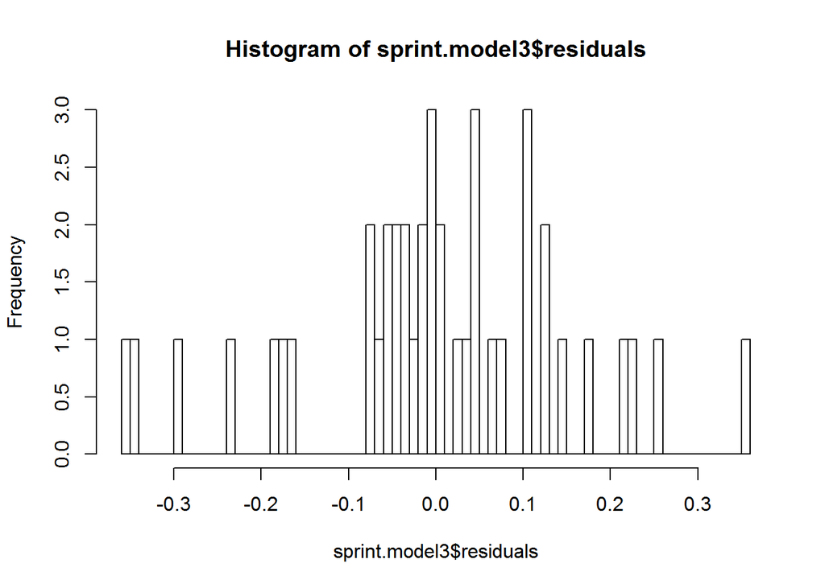

```r
hist(sprint.model3$residuals, breaks = 100)
```

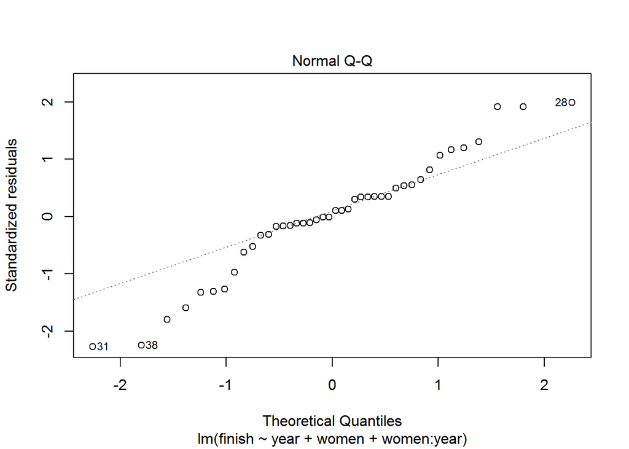

```r
#Q-Q Plot
plot(sprint.model1,2)
```

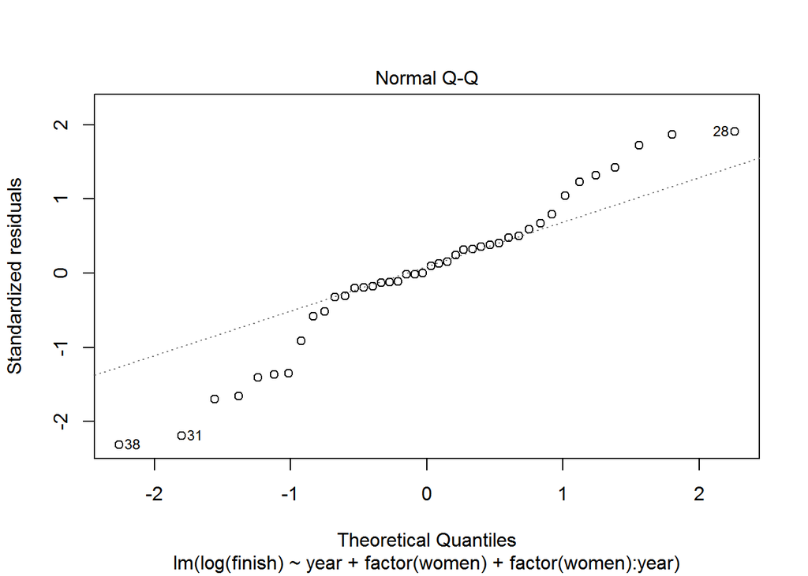

```r
plot(sprint.model2,2)
```

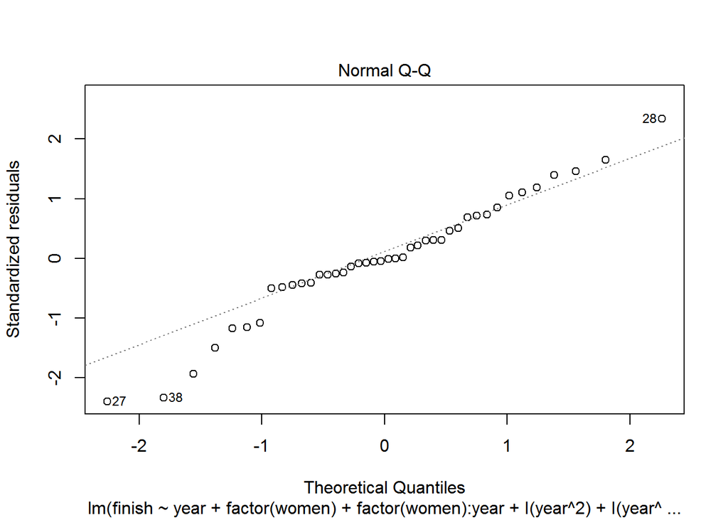

```r
plot(sprint.model3,2)
```

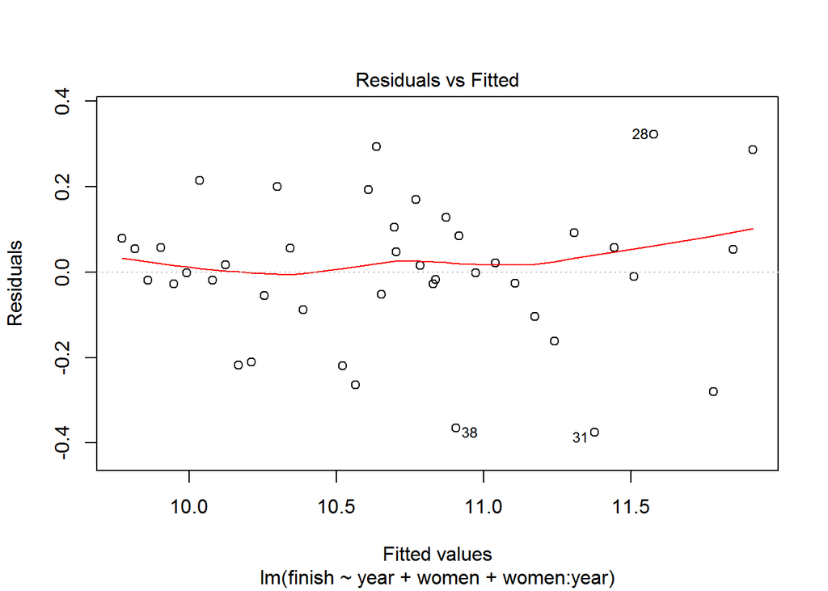

```r
#Residual v. Fitted Plot
plot(sprint.model1,1)
```

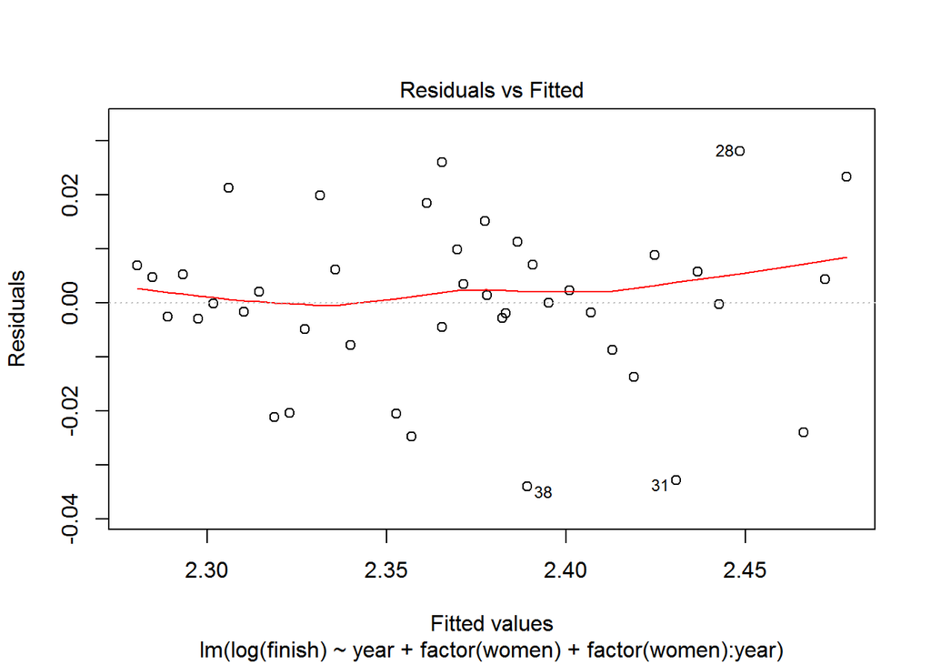

```r
plot(sprint.model2,1)
```

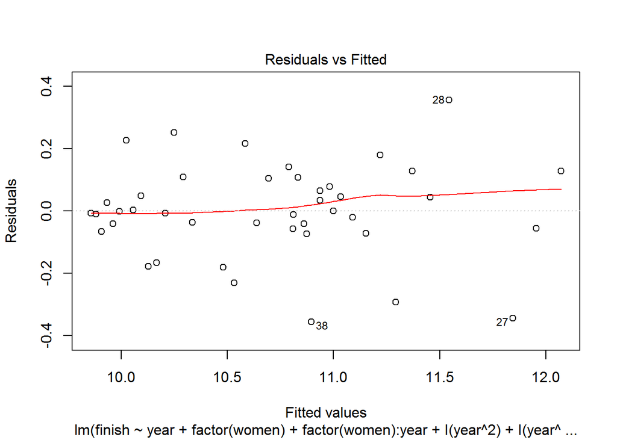

```r
plot(sprint.model3,1)
```

###### Condition 3: Constant Variability

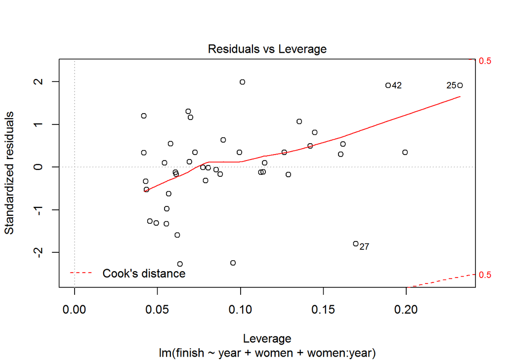

```r
#Residuals v. Leverage Plot w/Cook's Distance
plot(sprint.model1,5)
```

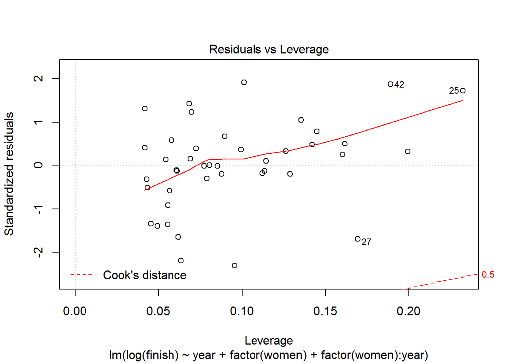

```r
plot(sprint.model2,5)
```

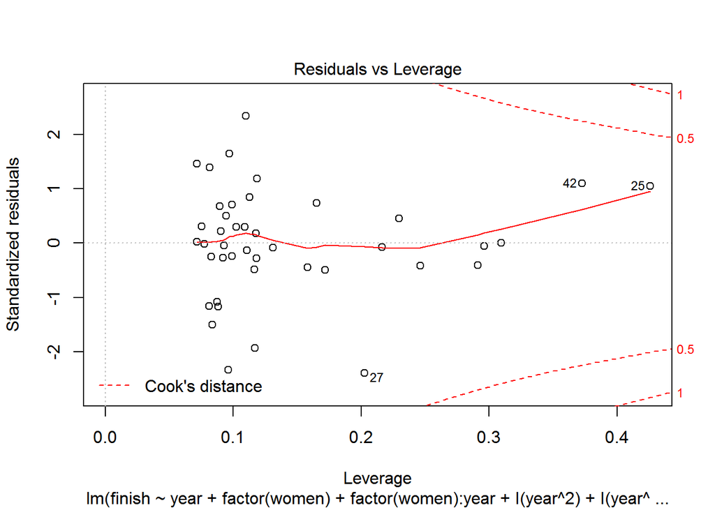

```r
plot(sprint.model3,5)
```

```r
#I could have done this, but I like the previous plots better...
#par(mfrow = c(2,2))
#plot(sprint.model1)
#plot(sprint.model2)
#plot(sprint.model3)
```

*Of the three models specified, I find Model3 to be the “best” model because the distribution of the residuls are relatively normally distributed, the residuals seem to be randomly distributed around zero, and the residual variance appears to be more constant across finish times in this model (less heteroskedasticity). Additionally, the plot of standardized residuals is better in Model3 because the red line is flatter in Model 3 compared to the others and two of the potentially high leverage points(42,25) are closer to the mean0.*

9. (6 points) Do these models have different predictions for the Olympics of 2156? Why or why not?

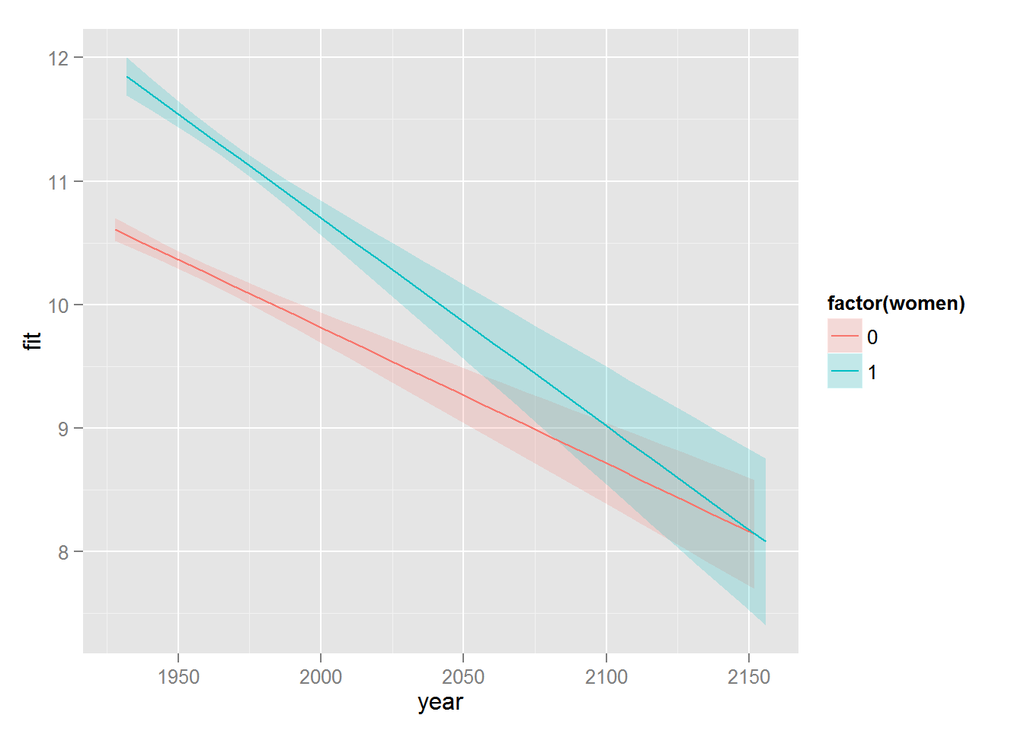

```r
year_hyp <- seq(from = 1928, to = 2156, by = 4)

pred1_df <- data.frame(year = year_hyp, women = c(0,1))
pred1 <- predict(sprint.model1, newdata = pred1_df, interval = "confidence")
pred1 <- cbind(pred1, pred1_df)

pred2_df <- data.frame(year = year_hyp, women = c(0,1))
pred2 <- predict(sprint.model2, newdata = pred2_df, interval = "confidence")
pred2 <- cbind(pred2, pred2_df)

pred3_df <- data.frame(year = year_hyp, women = c(0,1))
pred3 <- predict(sprint.model3, newdata = pred3_df, interval = "confidence")
pred3 <- cbind(pred3, pred3_df)

ggplot(pred1, aes(x = year, y = fit, ymin = lwr, ymax = upr, colour = factor(women), fill = factor(women))) + geom_ribbon(alpha = 0.2, colour = NA) + geom_line()
```

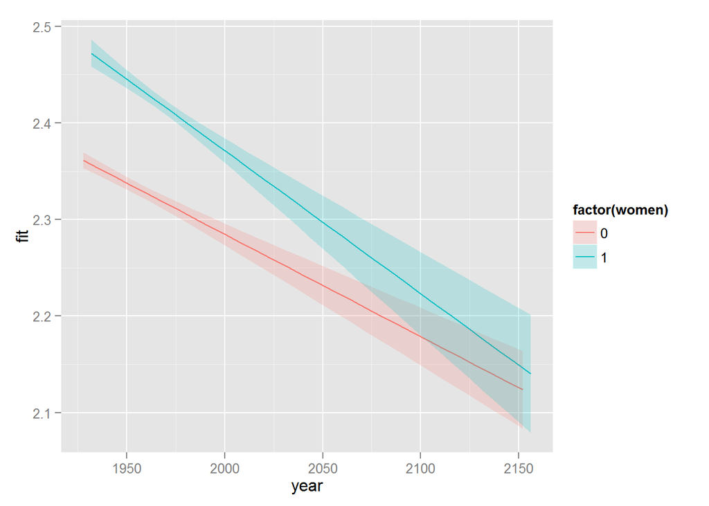

```r
ggplot(pred2, aes(x = year, y = fit, ymin = lwr, ymax = upr, colour = factor(women), fill = factor(women))) + geom_line() + geom_ribbon(alpha = 0.2, colour = NA)
```

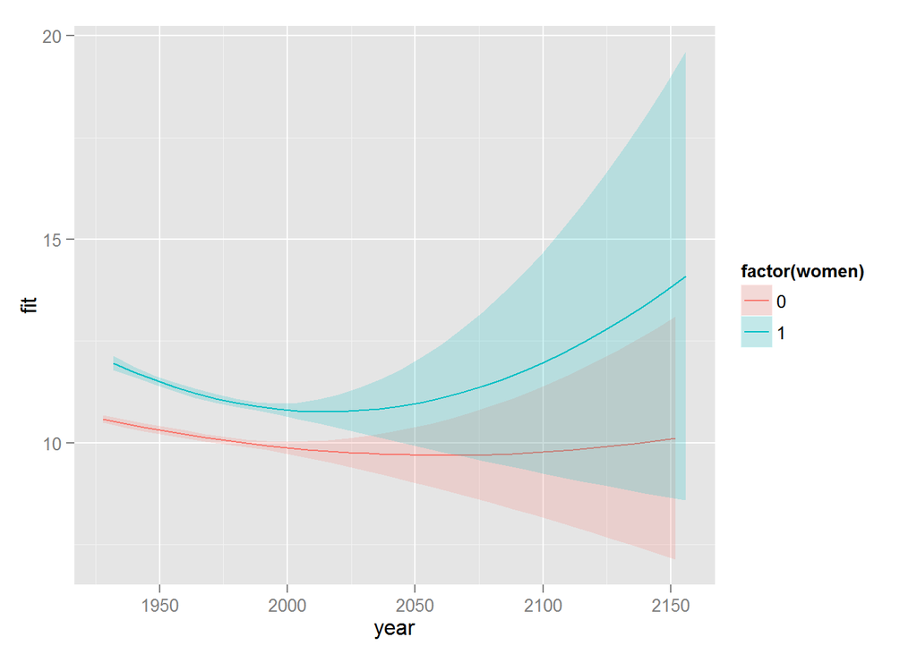

```r
ggplot(pred3, aes(x = year, y = fit, ymin = lwr, ymax = upr, colour = factor(women), fill = factor(women))) + geom_line() + geom_ribbon(alpha = 0.2, colour = NA)
```

```r
#Women
pred1 <- predict(sprint.model1, newdata = data.frame(year = 2156, women = 1), interval = "confidence") %>% as.data.frame()
pred2 <- predict(sprint.model2, newdata = data.frame(year = 2156, women = 1), interval = "confidence") %>% as.data.frame()
pred3 <- predict(sprint.model3, newdata = data.frame(year = 2156, women = 1), interval = "confidence") %>% as.data.frame()
library(stargazer);library(knitr)
stargazer(pred1,pred2,pred3,type='text',omit.stat=c("f", "rsq"),column.labels = c('M1',"M2","M3"),model.names = F,model.numbers = F)
```

```
##
## ======================================
## Statistic N Mean  St. Dev.  Min   Max
## --------------------------------------
## fit       1 8.079          8.079 8.079
## lwr       1 7.404          7.404 7.404
## upr       1 8.753          8.753 8.753
## --------------------------------------
##
## ======================================
## Statistic N Mean  St. Dev.  Min   Max
## --------------------------------------
## fit       1 2.140          2.140 2.140
## lwr       1 2.079          2.079 2.079
## upr       1 2.201          2.201 2.201
## --------------------------------------
##
## =========================================
## Statistic N  Mean  St. Dev.  Min    Max
## -----------------------------------------
## fit       1 14.101          14.101 14.101
## lwr       1 8.584           8.584  8.584
## upr       1 19.618          19.618 19.618
## -----------------------------------------
```

```r
#Men
pred1.male <- predict(sprint.model1, newdata = data.frame(year = 2156, women = 0), interval = "confidence") %>% as.data.frame()
pred2.male <- predict(sprint.model2, newdata = data.frame(year = 2156, women = 0), interval = "confidence") %>% as.data.frame()
pred3.male <- predict(sprint.model3, newdata = data.frame(year = 2156, women = 0), interval = "confidence") %>% as.data.frame()
stargazer(pred1.male,pred2.male,pred3.male,type='text',omit.stat=c("f", "rsq"),column.labels = c('M1',"M2","M3"),model.names = F,model.numbers = F)
```

```
##
## ======================================
## Statistic N Mean  St. Dev.  Min   Max
## --------------------------------------
## fit       1 8.098          8.098 8.098
## lwr       1 7.648          7.648 7.648
## upr       1 8.549          8.549 8.549
## --------------------------------------
##
## ======================================
## Statistic N Mean  St. Dev.  Min   Max
## --------------------------------------
## fit       1 2.119          2.119 2.119
## lwr       1 2.079          2.079 2.079
## upr       1 2.160          2.160 2.160
## --------------------------------------
##
## =========================================
## Statistic N  Mean  St. Dev.  Min    Max
## -----------------------------------------
## fit       1 10.158          10.158 10.158
## lwr       1 7.050           7.050  7.050
## upr       1 13.265          13.265 13.265
## -----------------------------------------
```

```r
par(mfrow = c(1,1))
```

10. (6 points) Now create a new variable, the ratio of men’s time to women’s time in each year. Log-transform this variable and regress it on year. Plot the results, with confidence intervals, on the scale of the ratio men’s time to women’s time (i.e., transform it back from the natural logarithm).

```r
men_df <- sprinters %>% filter(women=='0') %>% select(year,finish) %>% slice(7:24)
men_df$men_finish <- men_df$finish
men_df$finish <- NULL
women_df <- sprinters %>% filter(women=='1') %>% select(year,finish) %>% slice(1:18)
women_df$women_finish <- women_df$finish
women_df$finish <- NULL
women_df$year_w <- women_df$year
women_df$year <- NULL

sprinters2 <- cbind(men_df,women_df)
sprinters2$year_w <- NULL

sprinters2 <- transform(sprinters2, ratio_mf = men_finish / women_finish)

sprint2.model1 <- lm(year ~ log(ratio_mf),data = sprinters2)
summary(sprint2.model1)
```

```
##
## Call:
## lm(formula = year ~ log(ratio_mf), data = sprinters2)
##
## Residuals:
##     Min      1Q  Median      3Q     Max
## -28.418 -15.529  -0.115  12.175  37.079
##
## Coefficients:
##               Estimate Std. Error t value Pr(>|t|)
## (Intercept)    2028.14      21.38  94.854   <2e-16 ***
## log(ratio_mf)   588.41     206.50   2.849   0.0116 *
## ---
## Signif. codes:  0 '***' 0.001 '**' 0.01 '*' 0.05 '.' 0.1 ' ' 1
##
## Residual standard error: 19.69 on 16 degrees of freedom
## Multiple R-squared:  0.3366, Adjusted R-squared:  0.2952
## F-statistic: 8.119 on 1 and 16 DF,  p-value: 0.0116
```

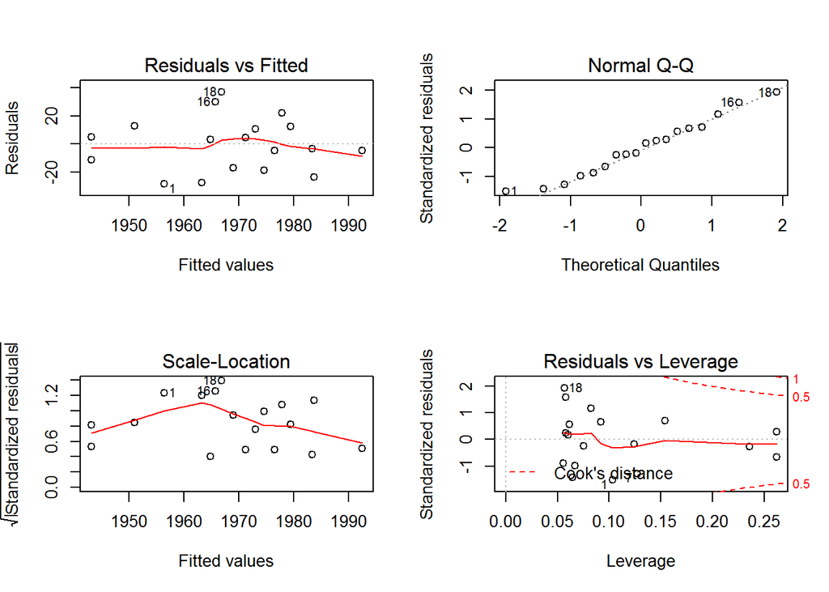

```r
par(mfrow = c(2,2))
plot(sprint2.model1)
```

```r
sprint2.model1.nolog <- lm(year ~ ratio_mf, data = sprinters2)
summary(sprint2.model1.nolog)
```

```
##
## Call:
## lm(formula = year ~ ratio_mf, data = sprinters2)
##
## Residuals:
##     Min      1Q  Median      3Q     Max
## -28.378 -15.508  -0.074  12.232  37.227
##
## Coefficients:
##             Estimate Std. Error t value Pr(>|t|)
## (Intercept)   1379.2      207.9   6.636 5.73e-06 ***
## ratio_mf       652.0      229.8   2.837   0.0119 *
## ---
## Signif. codes:  0 '***' 0.001 '**' 0.01 '*' 0.05 '.' 0.1 ' ' 1
##
## Residual standard error: 19.72 on 16 degrees of freedom
## Multiple R-squared:  0.3346, Adjusted R-squared:  0.293
## F-statistic: 8.046 on 1 and 16 DF,  p-value: 0.01191
```

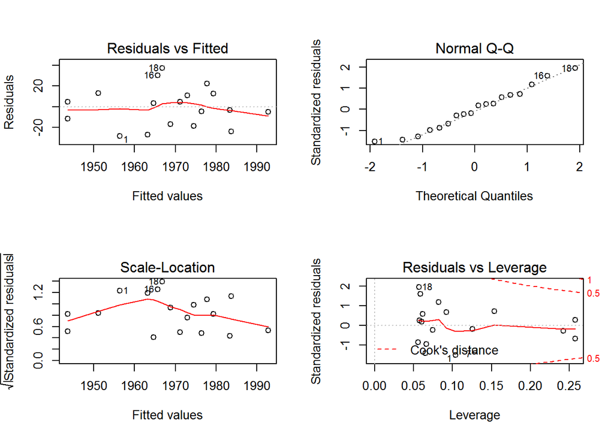

```r
plot(sprint2.model1.nolog)
```

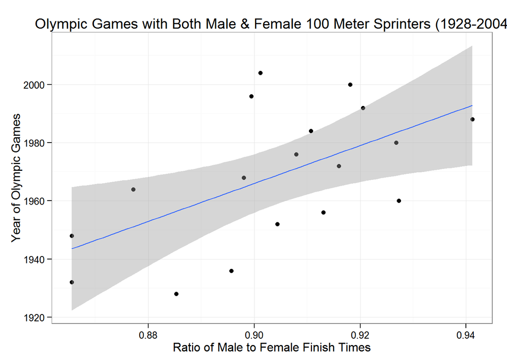

```r
par(mfrow = c(1,1))

ggplot(sprinters2,aes(x = ratio_mf, y = year)) + geom_point() + theme_bw() + scale_y_continuous('Year of Olympic Games') + scale_x_continuous('Ratio of Male to Female Finish Times') + geom_smooth(method = 'lm') + labs(title = ' Olympic Games with Both Male & Female 100 Meter Sprinters (1928-2004)')
```

*There were no finish times for women prior to 1928, so I dropped those observations and focused on the observations I could match from 1928-2004.*

*In general, I would interpret this graph as additional evidence that women are getting faster more quickly relative to men (the ratio of male to female finish times are increasing), whereas if women were getting slower or males were getting faster relative to females, the male to female ratio would be much lower.*